# Characterising rocky intertidal biodiversity using environmental DNA metabarcoding from local to national scales

Author

Simons D-L, Hipperson H, Webb TJ, Spencer M, Mieszkowska N

## Introduction

This pipeline replicates all analyses in Simons *et al* (2025) “Characterising rocky intertidal biodiversity using environmental DNA metabarcoding from local to national scales”.

## Load packages

Some packages require installation from Bioconductor using the `BiocManager::install()` command or directly from GitHub.

```r
#clear environment
rm(list = ls())

packages <- c("devtools",
              "qiime2R", #github download
              "microbiome", #github download
              "tidyverse",
              "vegan",
              "ggforce",
              "phyloseq",
              "ANCOMBC", #bioc install
              "DT",
              "ranacapa", #for ggrare, github download
              "plyr",
              "reshape2",
              "patchwork",
              "microViz",
              "microeco",
              "eulerr",
              "microbiomeutilities", #github install
              "ggtreeExtra", #bioc install
              "mgcv",
              "cowplot",
              "geosphere",
              "MiscMetabar",
              "ggVennDiagram",
              'lme4',
              "car",
              "ggsignif",
              "emmeans",
              "ggeffects",
              "gridExtra",
              "merDeriv",
              "ggrepel",
              "sf",
              "dada2" #bioc install
              )

new.packages <- packages[!(packages %in% installed.packages()[,"Package"])]
if(length(new.packages)) install.packages(new.packages)

invisible(lapply(packages, library, character.only = TRUE))
```

## Importing data and tidying

Let’s load our phyloseq object and long data, which have already been tidied, decontaminated, filtered for target taxa, and checked for quality control through [this pipeline](https://github.com/dinaleighsimons/intertidal-eDNA-formatting-and-quality-control).

```r
load("Input_Data/phylo_rocky_eDNA.RData")
phylo_rocky_eDNA_long <- read.csv("Input_data/phylo_rocky_eDNA_long.csv")
```

Let’s separate data sets for each primer.

```r
phylo_rocky_eDNA_CO1 <- ps_filter(phylo_rocky_eDNA, primer == "CO1")
phylo_rocky_eDNA_CO1
```

```
phyloseq-class experiment-level object
otu_table()   OTU Table:         [ 606 taxa and 263 samples ]
sample_data() Sample Data:       [ 263 samples by 42 sample variables ]
tax_table()   Taxonomy Table:    [ 606 taxa by 13 taxonomic ranks ]
```

```r
phylo_rocky_eDNA_18S <- ps_filter(phylo_rocky_eDNA, primer == "18S")
phylo_rocky_eDNA_18S
```

```
phyloseq-class experiment-level object
otu_table()   OTU Table:         [ 487 taxa and 242 samples ]
sample_data() Sample Data:       [ 242 samples by 42 sample variables ]
tax_table()   Taxonomy Table:    [ 487 taxa by 13 taxonomic ranks ]
```

Some of our data analysis (PERMANOVAs) is completed in PRIMER7, so we need to export elements of the `phylo` elements to use outside of R.

```r
#all
meta_target <- data.frame(sample_data(phylo_rocky_eDNA))
write.csv(meta_target, file = "Processed_Data/PRIMER7_format/meta_target.csv")

meta_target_t <- t(meta_target)
write.csv(meta_target_t, file = "Processed_Data/PRIMER7_format/meta_target_t.csv")

taxa_target <- data.frame(otu_table(phylo_rocky_eDNA))
write.csv(taxa_target, file = "Processed_Data/PRIMER7_format/taxa_target.csv")

taxonomy_table <- tax_table(phylo_rocky_eDNA)

# CO1
pseq_CO1 <- ps_filter(phylo_rocky_eDNA, primer == "CO1")

meta_target_CO1 <- data.frame(sample_data(pseq_CO1))
write.csv(meta_target_CO1, file = "Processed_Data/PRIMER7_format/meta_target_CO1.csv")

meta_target_CO1_t <- t(meta_target_CO1)
write.csv(meta_target_CO1_t, file = "Processed_Data/PRIMER7_format/meta_target_CO1_t.csv")

taxa_target_CO1 <- data.frame(otu_table(pseq_CO1))
write.csv(taxa_target_CO1, file = "Processed_Data/PRIMER7_format/taxa_target_CO1.csv")

# 18S
pseq_18S <- ps_filter(phylo_rocky_eDNA, primer == "18S")

meta_target_18S <- data.frame(sample_data(pseq_18S))
write.csv(meta_target_18S, file = "Processed_Data/PRIMER7_format/meta_target_18S.csv")

meta_target_18S_t <- t(meta_target_18S)
write.csv(meta_target_18S_t, file = "Processed_Data/PRIMER7_format/meta_target_18S_t.csv")

taxa_target_18S <- data.frame(otu_table(pseq_18S))
write.csv(taxa_target_18S, file = "Processed_Data/PRIMER7_format/taxa_target_18S.csv")
```

We also need some extra meta data for looking at ecological concordance.

```r
biogeo <- read.csv("Input_Data/marclim_categories_tidy.csv")
```

## Map of sampling sites

```r
#blank map
worldmap = map_data('world')
worldUk <- subset(worldmap, region == c('UK','Ireland'))

#convert to sf object
sf_data <- st_as_sf(worldUk, coords = c("long", "lat"), crs = 4326)  # Specify CRS as WGS84 (EPSG:4326)

# Get countries outline
UK <- rnaturalearth::ne_countries(
  country = c("United Kingdom", "Ireland"),
  scale = "large", returnclass = "sf"
)
```

```r
unique_data <- phylo_rocky_eDNA_long %>% distinct(decimalLongitude, decimalLatitude, verbatimLocality, .keep_all = TRUE)

# Define custom colors for each country
country_colors <- c("Scotland" = "darkseagreen3",
                    "North Wales" = "lightpink2",
                    "Northeast England" = "lightyellow2",
                    "South Wales" = "lightblue2",
                    "Southwest England" = "plum")
```

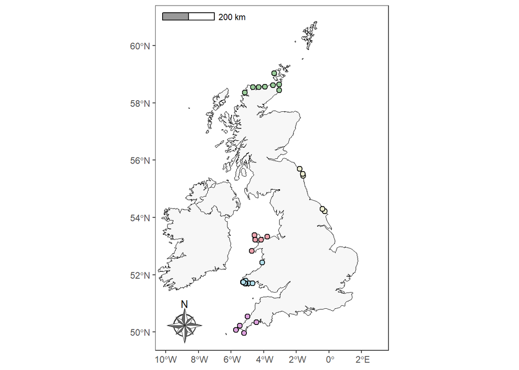

```r
site_map <- ggplot() +
  geom_sf(data = UK ,
          fill = 'grey97', color = 'black') +
  coord_sf(xlim = c(-10, 3), expand = TRUE) +
  scale_x_continuous(sec.axis = dup_axis()) +
  scale_y_continuous(sec.axis = dup_axis()) +
  theme_bw() +
  geom_point(data = unique_data,
             aes(x = as.numeric(decimalLongitude),
                 y = as.numeric(decimalLatitude),
                 fill = country),
             size = 2, alpha = 1,
             shape = 21,
             stroke = 0.6) +  # Adjusted size for better visibility
  scale_fill_manual(values = country_colors, guide = "none") +  # Apply custom colors and remove fill legend
  scale_color_discrete(name = "Region") +  # Changed legend name to 'Region'
  ggspatial::annotation_north_arrow(
    location = "bl", which_north = "true",
    style = ggspatial::north_arrow_nautical(
      fill = c("grey40", "white"),
      line_col = "grey20",
      text_family = "ArcherPro Book"
    )
  ) +
  ggspatial::annotation_scale(
    location = "tl",
    bar_cols = c("grey60", "white"),
    text_family = "ArcherPro Book"
  ) +
  theme(legend.position = "left",
        axis.title = element_blank(),
        panel.grid.major = element_blank(),
        panel.grid.minor = element_blank()
  )

ggsave(filename = "Figures/site_map_chpt1.png", plot = site_map,
       device = "png", dpi = 600, units = "mm", height = 200, width = 150)

site_map
```

## Sequence outputs

Explore what our `phyloseq` looks like.

```r
phylo_rocky_eDNA
```

```
phyloseq-class experiment-level object
otu_table()   OTU Table:         [ 1026 taxa and 505 samples ]
sample_data() Sample Data:       [ 505 samples by 42 sample variables ]
tax_table()   Taxonomy Table:    [ 1026 taxa by 13 taxonomic ranks ]
```

```r
microbiome::summarize_phyloseq(phylo_rocky_eDNA)
```

```
[[1]]
[1] "1] Min. number of reads = 0"

[[2]]
[1] "2] Max. number of reads = 278941"

[[3]]
[1] "3] Total number of reads = 9133664"

[[4]]
[1] "4] Average number of reads = 18086.4633663366"

[[5]]
[1] "5] Median number of reads = 7834"

[[6]]
[1] "7] Sparsity = 0.96266188022311"

[[7]]
[1] "6] Any OTU sum to 1 or less? NO"

[[8]]
[1] "8] Number of singletons = 0"

[[9]]
[1] "9] Percent of OTUs that are singletons \n        (i.e. exactly one read detected across all samples)0"

[[10]]
[1] "10] Number of sample variables are: 42"

[[11]]
 [1] "fieldID"               "projectID"             "eventID"
 [4] "type"                  "verbatimLocality"      "localityID"
 [7] "shorePosition"         "fullID"                "year"
[10] "month"                 "day"                   "eventTime"
[13] "dna_concentration_CO1" "dna_concentration_18S" "negCheckLogical"
[16] "pairedRepLogical"      "country"               "controlCheck"
[19] "sampleType"            "primer"                "date_amplified_CO1"
[22] "date_amplified_18S"    "batch_extraction"      "batch_PCR_CO1"
[25] "plate_col_CO1"         "plate_row_CO1"         "batch_PCR_18S"
[28] "plate_col_18S"         "plate_row_18S"         "date_extraction"
[31] "exposure"              "weather"               "tide"
[34] "lowWater"              "decimalLongitude"      "decimalLatitude"
[37] "eventTime.1"           "rockpoolarea.cm.2."    "averageDepth..cm."
[40] "rockpoolVol.m.3."      "averagePH"             "averageTemp"
```

```r
table(meta(phylo_rocky_eDNA)$controlCheck, useNA = "always") #sample type
```

```
sample   <NA>
   505      0
```

```r
table(meta(phylo_rocky_eDNA)$shorePosition, useNA = "always") #sample type
```

```
      High        Low Open Water       <NA>
       152        139        214          0
```

We can also look to see how many samples are across different categories like primer, sample type and site.

```r
table(meta(phylo_rocky_eDNA)$primer, useNA = "always") #Primer
```

```
 18S  CO1 <NA>
 242  263    0
```

```r
table(meta(phylo_rocky_eDNA)$sampleType, useNA = "always") #sample type
```

```
  failed-repeat plate-replicate   run-replicate          sample            <NA>
              4              34              28             439               0
```

```r
table(meta(phylo_rocky_eDNA)$type, useNA = "always") #rockpool vs tidal
```

```
    Open Rockpool     <NA>
     214      291        0
```

```r
table(meta(phylo_rocky_eDNA)$verbatimLocality, useNA = "always") #sites
```

```
     Aberystwyth Borwick, Yesnaby      Broad Haven Castlehead Rocks
              23               12               22               19
      Dale Jetty      Filey Brigg  Great Orme East      Little Orme
               9               17               18                7
    Lizard Point             Looe   Martin's Haven     Menai Bridge
              27               18                6               18
 Monkstone Point       Murkle Bay     Newton Point          Neyland
               5               22               18                6
       Porth Oer      Porth Swtan       Portskerra        Rhosneigr
              13               18                6               18
         Rispond    Rumbling Kern          Sannick     Scalby Mills
              11               16               11               19
         Scourie      Sennen Cove          Skerray    Skomer Island
              23               17               23                5
         St Ives          Trevone       West Angle             Wick
              19               19               23               17
            <NA>
               0
```

And let’s look at the `phyloseq` objects per primer.

```r
microbiome::summarize_phyloseq(phylo_rocky_eDNA_CO1)
```

```
[[1]]
[1] "1] Min. number of reads = 0"

[[2]]
[1] "2] Max. number of reads = 133841"

[[3]]
[1] "3] Total number of reads = 2697852"

[[4]]
[1] "4] Average number of reads = 10257.9923954373"

[[5]]
[1] "5] Median number of reads = 4970"

[[6]]
[1] "7] Sparsity = 0.940493669138777"

[[7]]
[1] "6] Any OTU sum to 1 or less? NO"

[[8]]
[1] "8] Number of singletons = 0"

[[9]]
[1] "9] Percent of OTUs that are singletons \n        (i.e. exactly one read detected across all samples)0"

[[10]]
[1] "10] Number of sample variables are: 42"

[[11]]
 [1] "fieldID"               "projectID"             "eventID"
 [4] "type"                  "verbatimLocality"      "localityID"
 [7] "shorePosition"         "fullID"                "year"
[10] "month"                 "day"                   "eventTime"
[13] "dna_concentration_CO1" "dna_concentration_18S" "negCheckLogical"
[16] "pairedRepLogical"      "country"               "controlCheck"
[19] "sampleType"            "primer"                "date_amplified_CO1"
[22] "date_amplified_18S"    "batch_extraction"      "batch_PCR_CO1"
[25] "plate_col_CO1"         "plate_row_CO1"         "batch_PCR_18S"
[28] "plate_col_18S"         "plate_row_18S"         "date_extraction"
[31] "exposure"              "weather"               "tide"
[34] "lowWater"              "decimalLongitude"      "decimalLatitude"
[37] "eventTime.1"           "rockpoolarea.cm.2."    "averageDepth..cm."
[40] "rockpoolVol.m.3."      "averagePH"             "averageTemp"
```

```r
microbiome::summarize_phyloseq(phylo_rocky_eDNA_18S)
```

```
[[1]]
[1] "1] Min. number of reads = 6"

[[2]]
[1] "2] Max. number of reads = 278941"

[[3]]
[1] "3] Total number of reads = 6435812"

[[4]]
[1] "4] Average number of reads = 26594.2644628099"

[[5]]
[1] "5] Median number of reads = 14091.5"

[[6]]
[1] "7] Sparsity = 0.916320192780898"

[[7]]
[1] "6] Any OTU sum to 1 or less? NO"

[[8]]
[1] "8] Number of singletons = 0"

[[9]]
[1] "9] Percent of OTUs that are singletons \n        (i.e. exactly one read detected across all samples)0"

[[10]]
[1] "10] Number of sample variables are: 42"

[[11]]
 [1] "fieldID"               "projectID"             "eventID"
 [4] "type"                  "verbatimLocality"      "localityID"
 [7] "shorePosition"         "fullID"                "year"
[10] "month"                 "day"                   "eventTime"
[13] "dna_concentration_CO1" "dna_concentration_18S" "negCheckLogical"
[16] "pairedRepLogical"      "country"               "controlCheck"
[19] "sampleType"            "primer"                "date_amplified_CO1"
[22] "date_amplified_18S"    "batch_extraction"      "batch_PCR_CO1"
[25] "plate_col_CO1"         "plate_row_CO1"         "batch_PCR_18S"
[28] "plate_col_18S"         "plate_row_18S"         "date_extraction"
[31] "exposure"              "weather"               "tide"
[34] "lowWater"              "decimalLongitude"      "decimalLatitude"
[37] "eventTime.1"           "rockpoolarea.cm.2."    "averageDepth..cm."
[40] "rockpoolVol.m.3."      "averagePH"             "averageTemp"
```

Check how many samples were collected per site. We can see we have an unbalanced sampling effort.

```r
meta_target$localityID = as.factor(meta_target$localityID)
meta_target$fieldID = as.factor(meta_target$fieldID)
meta_target$sampleType = as.factor(meta_target$sampleType)

# Count unique fieldIDs per site
fieldID_counts <- meta_target %>%
  dplyr::filter(sampleType == "sample") %>%  # Keep only 'sample' rows
  dplyr::group_by(localityID) %>%
  dplyr::summarise(num_fieldIDs = n_distinct(fieldID))

# View results
print(fieldID_counts) # 21 / 32 have full sampling effort
```

```
# A tibble: 32 × 2
   localityID num_fieldIDs
   <fct>             <int>
 1 CN01                  9
 2 CN02                  9
 3 CN03                  9
 4 CN04                  9
 5 CN05                  9
 6 NE01                  9
 7 NE02                  9
 8 NE03                  9
 9 NE04                  9
10 NE05                 10
# ℹ 22 more rows
```